# Workshop 4: Time series analyses for crop yield

Jacinta Holloway

23 May 2018

### Setting up your R session

Start by making sure that your working directory is properly set - it should be set to the same place your code and data for R script are stored. If not you can set it using setwd() To check your working directory use getwd. getwd()

Install and load required packages. This workshop requires the packages dlm, forecast and tseries. You can check which packages you have installed using the installed.packages function.

```r
options(repos="https://cran.rstudio.com")
installed.packages(lib.loc = NULL, priority = NULL,
                   noCache = FALSE, fields = NULL,
                   subarch = .Platform$r_arch)
```

If the dlm, forecast or tseries packages are not installed, run the following code:

options(repos=“https://cran.rstudio.com”) install.packages (c(“dlm”, “forecast”, “tseries”))

Load the libraries for the required packages.

```r
library(dlm)
library(forecast)
library(tseries)
```

We will be working on crop data that is freely available and extracted from the FAO website http://www.fao.org/faostat/en/#data/QC

Read the crop data from a csv file into R, calling the data yield.data. Change the file path to the location of the csv file on your computer.

```r
yield.data <-read.csv("data/FAOSTAT_data_crop_yield_Rwanda.csv")
```

View the first few rows of the data to see how it looks. Also check the structure.

```r
head(yield.data)
str(yield.data)
```

```r
colnames(yield.data)[8] <- "Crop"
head(yield.data)
```

Create a plot of the yield value of Maize over time.

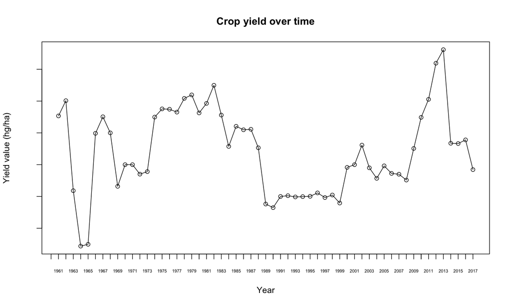

```r
plot(yield.data$Value, type = "o",
     xlab = "Year",
     ylab = "Yield value (hg/ha)",
     main = "Crop yield over time",
     labels = FALSE)
axis(1, at=1:57, labels=yield.data$Year[1:57], cex.axis = 0.5)
```

### Fit an Auto-Regressive Time Series Model (ARMA)

ARMA models are common in working with time series data.

```r
yield <-c(yield.data$Value)
yield.ts<- ts(data = yield, start = c(1980), end=c(2016), deltat =1)
```

Create a plot of crop yield, using the object yield, and fit an abline.

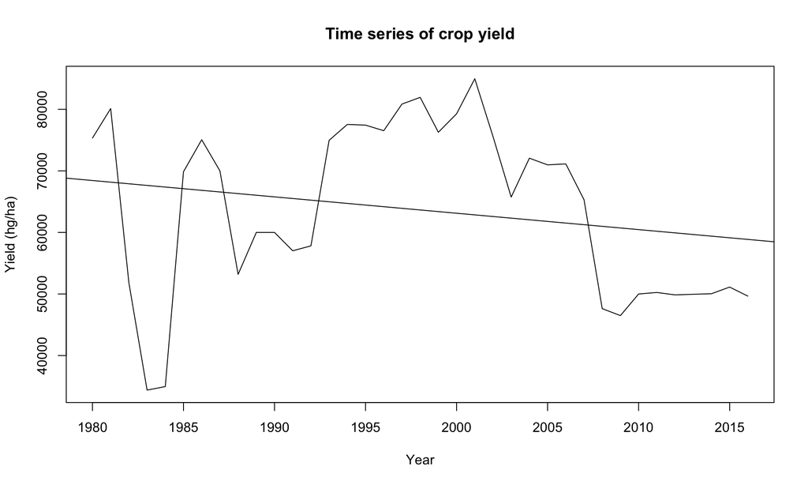

```r
plot(yield.ts, xlab = "Year", ylab = "Yield (hg/ha)", main = "Time series of crop yield")
abline(reg=lm(yield.ts~time(yield.ts)))
```

**Task** Interpret the graph. What is happening to yield over time?

Test the stationarity of the data by removing unequal variances using a log transformation and taking the difference of the series. We will use the Augmented Dickey-Fuller test (adf).

```r
tseries::adf.test(diff(log(yield.ts)), alternative="stationary", k=0)
```

The p value = .01 which indicates the series is stationary enough to use time series models.

Next, fit an ACF plot to the log of the yield data. The ACF plots the total correlation between different lag functions. If we have an autoregressive series, then the correlation will gradually decrease. If we have a moving average series, the total correlation in the plot cuts off at the nth lag.

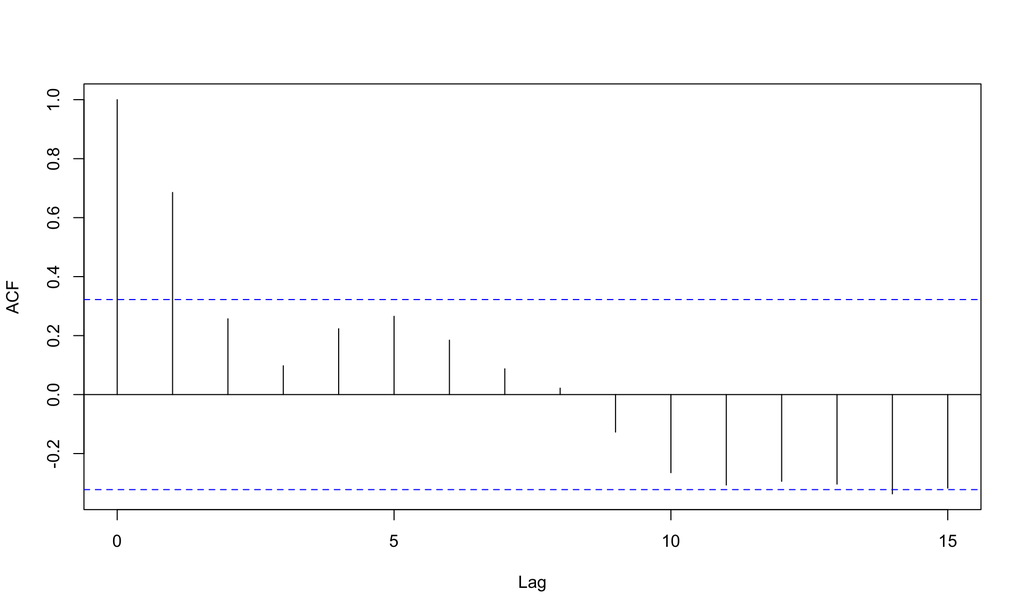

```r
acf(log(yield.ts), main = "")
```

There is a downward trend, so the series may not be stationary. A common way to create a possibly stationary series, is to examine the first differences. A useful definition, along with some time series analyses guidance in R is available here:https://www.analyticsvidhya.com/blog/2015/12/complete-tutorial-time-series-modeling/

Differencing : This is the commonly used technique to remove non-stationarity. Here we try to model the differences of the terms and not the actual term. For instance, x(t) – x(t-1) = ARMA (p , q)

This differencing is called as the Integration part in AR(I)MA. Now, we have three parameters p : AR

d : I

q : MA

To find the parameters p, d and q we can use Auto Correlation Function (ACF) plots. The code below plots an ACF of the first order differences for the log of crop yield.

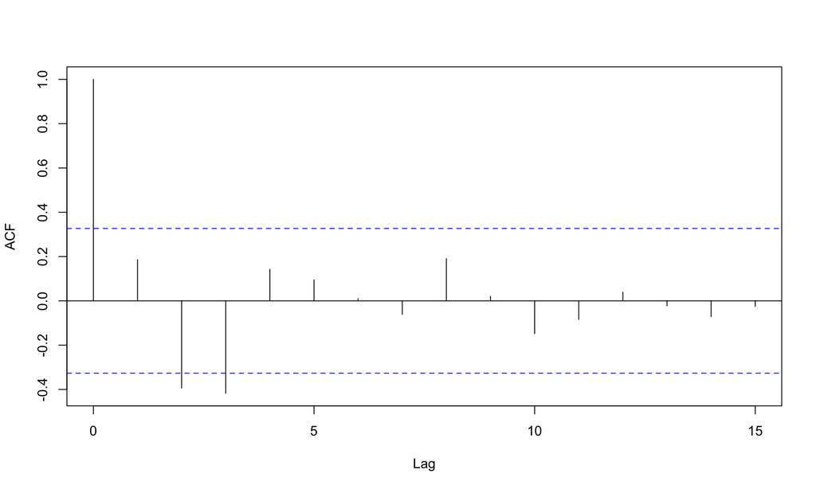

```r
acf(diff(log(yield.ts)), main = "")
```

An ARIMA is an Auto-Regressive Integrated Moving Averages model. Using this type of model, predict log of crop yield in the next two years using the forecast package.

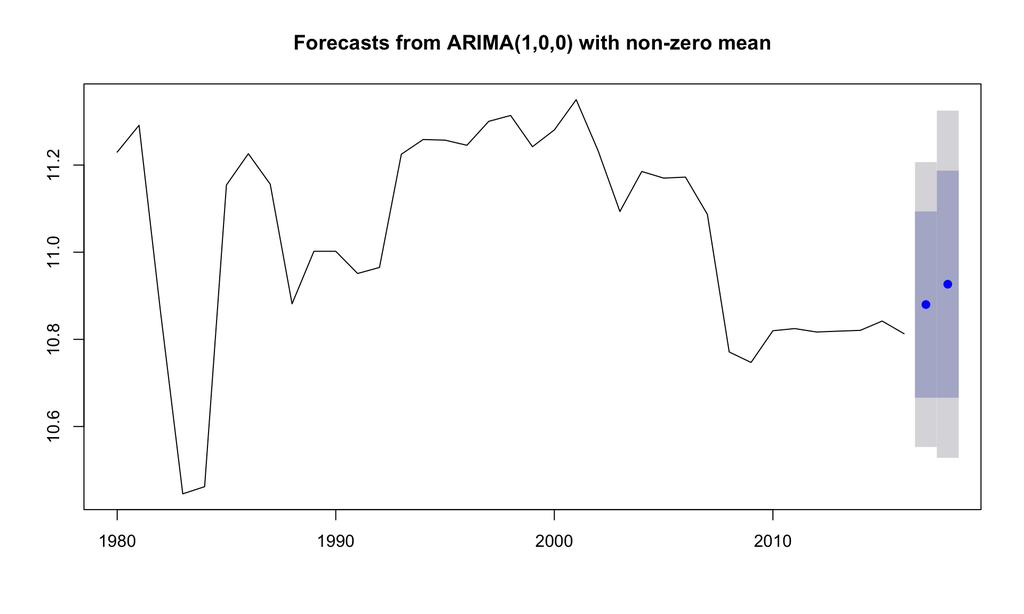

```r
fit <- arima(log(yield.ts), order= c(1, 0, 0))
forecast(fit, 2)
plot(forecast(fit, 2))
```

**Task** Add a title and labels to this plot. Choose a different number of years to forecast and write code based on this example to produce these predictions of crop yield.

## Extension examples: a structural time series model and state space model

### Crop yield State Space Model example - Linear Gaussian Trend Plus Seasonality

This example is based on package dlm example (https://cran.r-project.org/web/packages/dlm/vignettes/dlm.pdf)

### Fit a structural time series model

Fit a structural Time series model to this data with local linear trend plus quarterly seasonality component. See notes for model details.

Step 1 is to build the model with the built in structures in dlm. Default order for dlmModPoly = 2, which represents a stochastic linear trend (mean plus slope).

```r
options(scipen="999")
yield.mod <- dlmModPoly() + dlmModSeas(4)
yield.mod
```

$FF is the observation equation matrix (column 1 is trend, column 3 is seasonal component)

$V is observation equation error var-covar (needs to be estimated, see below)

$GG is the state transition matrix: (5 states: see model details in notes and note “sum to zero” seasonality constraints)

$W is the state equation var-covar matrix (trend level has zero var, slope and seasonality have error - vars need to be estimated, see below) $m0 and $C0 are t = 0 starting values for Gaussian states’ mean vector and var-covar matrix

Next create a function involving unknown parameters to be estimated using maximum likelihood. In this case these parameters are the unknown variances in the model.

```r
estimFun <- function(x) {
  diag(W(yield.mod))[2:3] <- exp(x[1:2])
  V(yield.mod) <- exp(x[3])
  return(yield.mod)
}
```

Note since the parameters are variances, parameterise as exp() for unconstrained optimisation. Now we use the function dlmMLE to obtain Maximum Likelihood Estimates (this function uses R’s built in ‘optim’ function)

```r
fit <- dlmMLE(yield.ts, parm = rep(0.1, 3), build = estimFun) # parm = rep(0.1,3) are starting vals
```

Check convergence. We want this to be zero.

```r
fit$conv
```

Now add these Maximum Likehlihood Estimates back into the State Space Model specification, yield.mod. Also check the var-covars have been updated.

```r
yield.mod <- estimFun(fit$par)
yield.mod$V; yield.mod$W
```

The function dlmSmooth uses the Kalman Smoother algorithm to get smoothed values of the states plus var-covar matrices. It returns a time series of smoothed state vectors (object$s), plus a SVD representation of the var-cov matrices. Note that the smoothed series begins one time unit before the first data observation (t-1), so we need to remove it for graph:

```r
yield.smooth <- dlmSmooth(yield.ts, mod = yield.mod)
```

Create graph showing original series decomposed into smoothed trend and seasonal components.

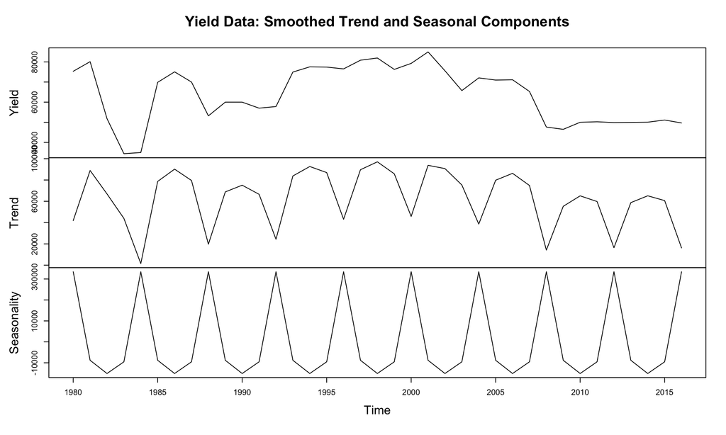

```r
x <- cbind(yield.ts, dropFirst(yield.smooth$s[,c(1,3)])) # note we drop the first row which is t-1 (see above)
colnames(x) <- c("Yield", "Trend", "Seasonality")
plot(x, main = "Yield Data: Smoothed Trend and Seasonal Components")
```

### Making crop yield predictions

We can also predict future values of the series based on the model. Let’s forecast 2 years ahead of the series (annually, so that’s 2 time steps) to 2018.

dlmFilter uses the Kalman Filter to compute filtered values of the states and var-covar matrices via SVD. An illustrated example of how a Kalman filter works http://www.bzarg.com/p/how-a-kalman-filter-works-in-pictures/ Note that the filtered series begins one time unit before the first data observation.

```r
yield.filter <- dlmFilter(yield.ts, mod = yield.mod)
```

The function dlmForecast calculates the expected value and variances of future observations and states.

```r
yield.forecast <- dlmForecast(yield.filter, nAhead = 2) # 2 indicates 2 time points (2 years from 2016 to 2018)
```

We are going to forecast the deseasonalised series (ie just trend), and we need the trend std.deviations to create prediction intervals. dlmForecast produces a list object of var-covar matrices, R (each element corresponding to the forecast time). We can access the trend standard deviation using the following function.

```r
std.devs <- sapply(yield.forecast$R, function(x) sqrt(x[1,1]))
std.devs
```

As we get further into the future making predictions, the standard deviations are getting larger. This is expected because it is difficult to forecast accurately! Just ask the weatherman…

Create the upper and lower 95% prediction intervals (everything is assumed Gaussian):

```r
fm <- yield.forecast$a[,1] # forecasted trend means (deseasonalised forecast)
pu <- fm + qnorm(0.975, sd = std.devs)
pl <- fm + qnorm(0.025, sd = std.devs)
```

```r
x <- ts.union(window(yield.ts, start = c(1)),         # Data
              window(yield.smooth$s[,1], start = c(1)), # Smoothed trend
              yield.forecast$a[,1],                     # Forecast trend
              pu, pl)                                   # upper and lower 95% prediction intervals for trend

x
```

Now plot on a single graph.

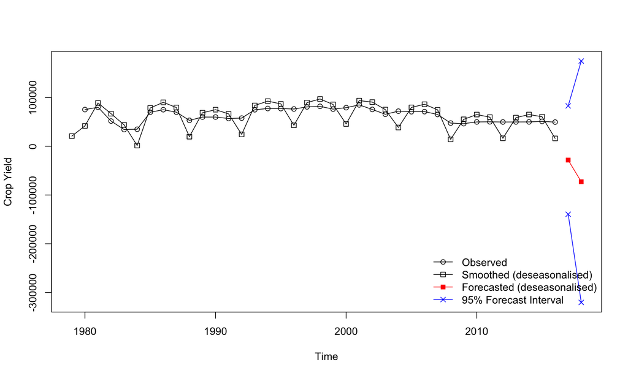

```r
plot(x, plot.type = "single", type = "o", pch = c(1, 0, 15, 4, 4),
     col = c("black", "black", "red", "blue", "blue"),
     ylab = "Crop Yield")
legend("bottomright", legend = c("Observed",
                                "Smoothed (deseasonalised)",
                                "Forecasted (deseasonalised)",
                                "95% Forecast Interval"),
       bty = 'n', pch = c(1, 0, 15, 4, 4), lty = 1,
       col = c("black", "black", "red", "blue", "blue"))
```